# R VideoGames Data

#### R Notebook - Verdieping beroepsproduct ICT Business

In dit document zal ik 5 SQL chunks uitwerken en 5 plots maken met GGPLOT. Hiervoor zal ik wat packages nodig hebben die we in de eerste chunk zullen inladen

```r
library("tidyverse") # De library tidyverse gebruik ik voor filters etc.
library("csvread") # library om Excel bestanden in te kunnen lezen.
library("lubridate")# library om een numerieke waarde terug te krijgen bij datums.
library("dplyr")# library voor onder andere SQL
library("RMySQL")# library voor sql connectie
```

#### Dataset inladen via sql

Om sql te gebruiken binnen onze R studio omgeving zullen we een connectie moeten leggen met een database.

```r
con = dbConnect(MySQL(),
                user='root',
                password='',
                dbname='games',
                host='127.0.0.1')
```

#### SQL query voor ophalen van game data per genre

Dit is de eerste SQL chunk die we maken hierbij vragen we aan de database om ons informatie terug te geven over games met het genres uit 2009.

```sql
SELECT `Rank`, `Genre`, SUM(`Global_Sales`) AS `TotalSalesInMillions`, `Year`
  FROM `games_data`
    WHERE `Year` = "2009"
      GROUP BY `Genre`;
```

## Populairste game-genre in 2009 over de hele wereld

Uit deze grafiek kunnen we herleiden dat Action games toch wel echt een groot deel uitmaken van de game industire met sports games. Als we dit vergelijken met andere games zien we dat de andere niet dichtbij komen. Als we dit ook vergelijken met andere jaren zien we nogsteeds een dominante marktpositie

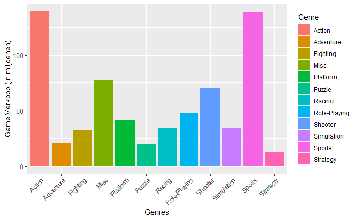

```r
ggplot(data=gamesdf_genre,
  aes(x=Genre, y=TotalSalesInMillions, fill = Genre)) +
  geom_bar(stat="identity") +
    theme(axis.text.x = element_text(angle = 45, vjust = 1, hjust = 1)) +
       labs(y = "Game Verkoop (in miljoenen)", x = "Genres")
```

#### SQL query voor ophalen van game data per genre

Hier heb ik een simpele query gebruikt om bij de volgende plot aan te tonen dat ik ervaring heb met lubridate

```sql
SELECT *
  FROM `games_data`
```

## Hoeveel games zijn er uitgekomen sinds 2009 per genre

Door deze chunk kunnen we ook goed zien waarom de Action en sports games zo hoge verkopen hebben. Er worden namelijk veel van dit soort games uitgebracht, game makers zouden ook geen games maken die mensen niet willen spellen dus je kan ook hieruit zien dat de game makers action games want die verkopen ook goed.

[figure not shown]

```r
games %>%
  mutate(DATE = as.Date(Year, format = "%Y")) %>%
  select(Year, Genre) %>%
    filter(Year >= 2009) %>%
      ggplot(aes(Genre, fill=Genre)) +
      geom_bar(stat = "count", fill="#f8766d") +
      stat_count(geom = "text",colour = "Black", aes(label = ..count..),position=position_stack(vjust=0.5)) +
      theme(axis.text.x = element_text(angle = 45, vjust = 1, hjust = 1)) +
  labs(title = "Action games sinds 2000",
           y = "Aantal releases",
           x = "Game genres")
```

#### SQL query voor ophalen van aantal Action games op de X360 of XOne

[output not shown]

## Grootste Action games op de X360 of XOne

De xbox is een populaire console geweest en er zijn veel games op uitgekomen, deze dataset bevat niet veel XOne platform games door de oudheid van de dataset. Alleen zien we wel dat de populaiste game Grand theft auto is uit het action genre.

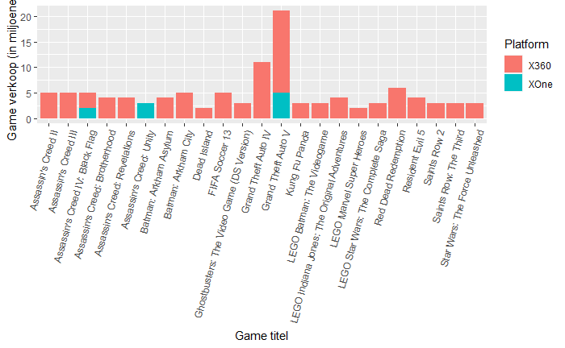

```r
ggplot(data=gamesdf_nintendo_nes,
  aes(x=Name, y=Global_Sales, fill =Platform)) +
    geom_bar(stat="identity") +
    theme(axis.text.x = element_text(angle = 75, vjust = 1, hjust = 1)) +
       labs(y = "Game verkoop (in miljoenen)", x = "Game titel")
```

#### Top 5 Pokemon games tussen 1996-2015 op basis van verkoop

```sql
SELECT * FROM `games_data`
  WHERE Name LIKE '%Pokemon%' OR   Name LIKE '%Pokémon%'
    AND `Year` BETWEEN 1996 AND 2015
      ORDER BY Global_Sales DESC, Global_Sales DESC
        LIMIT 5;
```

```r
ggplot(data=gamesdf_nintendo_pokemon,
  aes(x=Name, y=Global_Sales, fill =Platform)) +
    geom_bar(stat="identity") +
    theme(axis.text.x = element_text(angle = 45, vjust = 1, hjust = 1)) +
       labs(y = "Game verkoop (in miljoenen)", x = "Game titel")
```

[output not shown]

#### Wie is de grootste Publisher op basis van sales

dit is intressant om te weten om daarna ook te zien hoe oud de publisher is en zo dus ook te weten of ze per jaar veel games nog uitbrengen

```sql
SELECT Publisher, SUM(Global_Sales)
  AS Global_Sales_In_Millions
    FROM games_data
      GROUP BY Publisher
        ORDER BY Global_Sales DESC
          LIMIT 1;
```

```sql
SELECT games_data.Publisher, SUM(Global_Sales) AS Global_Sales_In_Millions, Founded
    FROM games_data
      INNER JOIN publisher_data
      ON publisher_data.Publisher  = games_data.Publisher
      GROUP BY publisher_data.Publisher
        ORDER BY Global_Sales DESC
          LIMIT 1;
```

```r
# dit is de grootste publisher print(gamesdf_biggest_publisher)

# hierbij krijgen we ook de founded date van de grootste publisher
print(gamesdf_biggest_publisher_founded_data)
```

| Publisher | Global_Sales_In_Millions | Founded |
| --- | --- | --- |
| Nintendo | 1750 | 1889-09-23 |

#### Deze SQL chunk heb ik gebruikt om aan te tonen dat ik een inner join beheers

```sql
SELECT games_data.Publisher, SUM(Global_Sales) AS Global_Sales_In_Millions, Founded, CURDATE() AS DateOfToday
    FROM games_data
      INNER JOIN publisher_data
      ON publisher_data.Publisher  = games_data.Publisher
      GROUP BY publisher_data.Publisher
```

## Oudste game studios

Hieruit kan je zien dat Nintendo en Cdeco vergeleken met de andere game studios relatief oud zijn en daarom ook meer sales hebben doordat ze al langer mee gaan dan de concurrenten

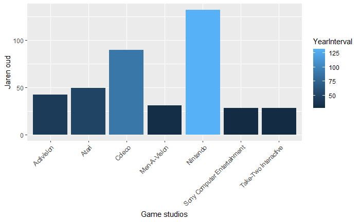

```r
publisherdf_interval <- publisherdf %>%
  #interval is van lubridate
  mutate(YearInterval = interval(Founded, DateOfToday) / years(1))

ggplot(data=publisherdf_interval,
  aes(x=Publisher, y=YearInterval, fill = YearInterval)) +
  geom_bar(stat="identity") +
    theme(axis.text.x = element_text(angle = 45, vjust = 1, hjust = 1)) +
       labs(y = "Jaren oud", x = "Game studios")
```